# Time Series Modelling

### ARMA Models, Decomposition of Time Series , Looking at trend, seasonality. Autocorrelation test and test for stationarity

```r
rm(list = ls())
cat("\f")
```

Install packages if you have never installed them.

```r
#install.packages("xlsx")
#install.packages("rJava")
#install.packages("tseries")
```

Loading packages

```r
library(tseries)
library(rJava)
library(xlsx)
```

Part I. Constructing prediction models for different variables

Read in data

```r
datas1 = read.xlsx('time_series_data_2017.xlsx',1,rowIndex = 11:826,colIndex = 1:2);
datas2= read.xlsx('time_series_data_2017.xlsx',2,rowIndex = 11:839,colIndex = 1:2);
datas3 = read.xlsx('time_series_data_2017.xlsx',3,rowIndex = 11:839,colIndex = 1:2);
datas4 = read.xlsx('time_series_data_2017.xlsx',4,rowIndex = 8:1761,colIndex = 1:2);
```

### Unemployment Rate

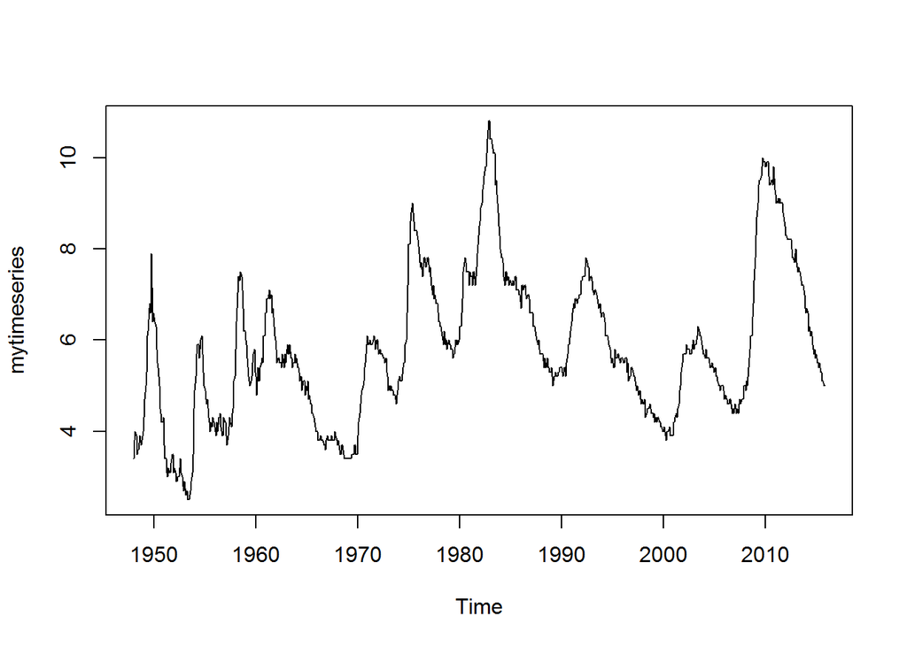

```r
mytimeseries = ts(data = datas1$UNRATE, start = 1948, frequency = 12)
plot(mytimeseries)
```

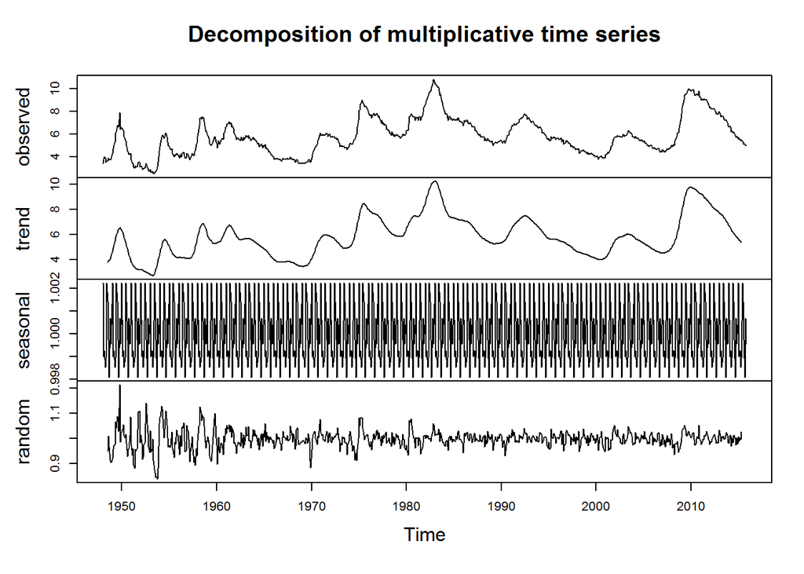

```r
#class(mytimeseries)
# decompose(mytimeseries, "multiplicative") # decompose is in R base
plot(decompose(mytimeseries, type = "multiplicative"))
```

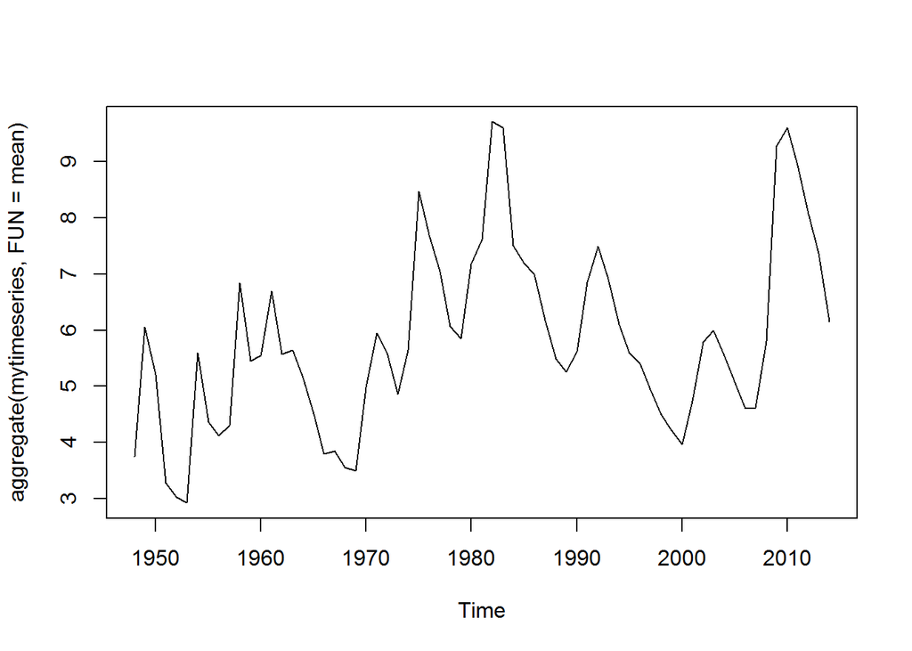

```r
plot(aggregate(mytimeseries,FUN=mean))
```

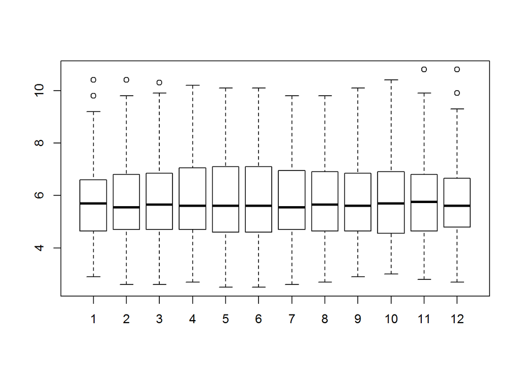

```r
boxplot(mytimeseries~cycle(mytimeseries))
```

Plot raw data

### Part 1

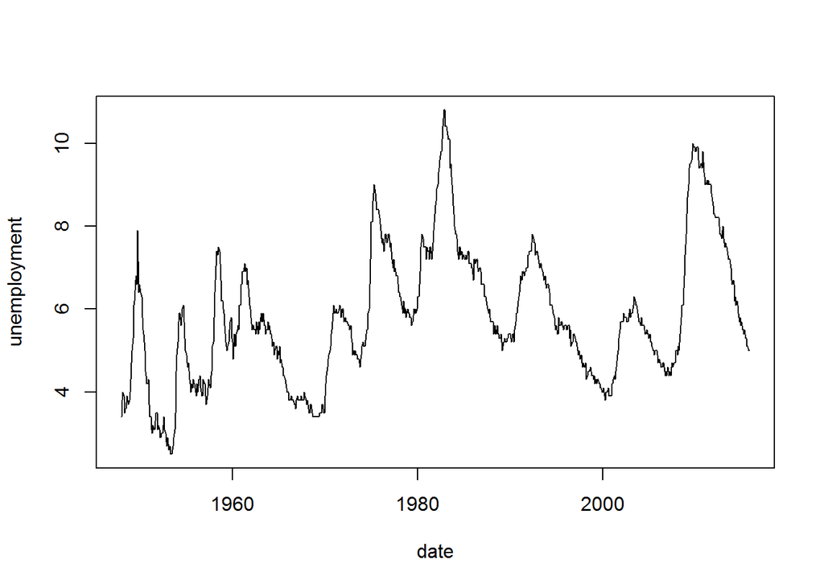

```r
plot(datas1$observation_date, datas1$UNRATE, xlab = 'date', ylab = 'unemployment', type='l')
```

Augmented Dickey-Fuller test for non-stationarity

```r
urate = datas1$UNRATE
pValue = adf.test(urate,k=1)$p.value
pValue
```

```
## [1] 0.5351543
```

The (augmented) Dickey-Fuller test indicates non-stationarity.

### Part 2

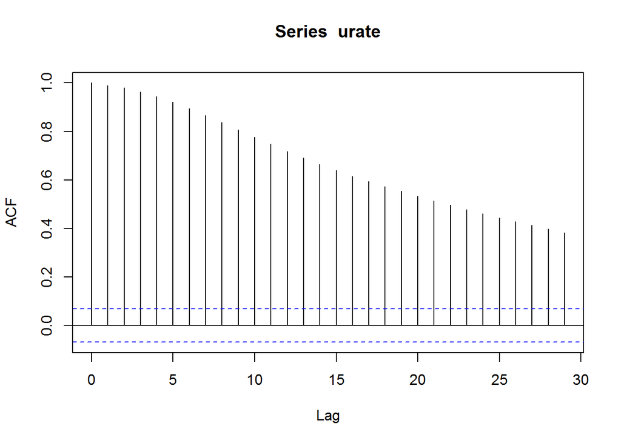

```r
acf(urate)
urateAutocorrs = acf(urate)$acf
```

Perform LBQ tests for significance of autocorrelations

```r
Box.test(urate, lag = 1)
```

```
##
##  Box-Pierce test
##
## data:  urate
## X-squared = 799.17, df = 1, p-value < 0.00000000000000022
```

```r
Box.test(urate, lag = 10)
```

```
##
##  Box-Pierce test
##
## data:  urate
## X-squared = 6607.9, df = 10, p-value < 0.00000000000000022
```

The serial correlation is statistically significant. i.e there is correlation

### Part 3

Test out different combinations of AR and MA terms and use AIC and BIC to determine fit

```r
maxAR = 4; # max of 4 AR terms
maxMA = 4; # max of 4 MA terms

urateModelCriteria = matrix(0,(maxAR+1)*(maxMA+1)-1,2)
ind = 1
lagCombinations = urateModelCriteria
```

Double for loop over AR and MA lags

```r
for(ii in 0:maxMA){
  for (jj in 0:maxAR) {
    if(ii != 0 || jj != 0){
      urateModelCriteria[ind,1] = AIC(arima(urate, order = c(ii, 0 ,jj)))
      urateModelCriteria[ind,2] = BIC(arima(urate, order = c(ii, 0 ,jj)))
      lagCombinations[ind,] = matrix(c(ii,jj),1,2)
      ind = ind+1
    }

  }
}
```

Find models with lowest AIC and BIC criteria, corresponding to best statistical fit

```r
minIndices = apply(urateModelCriteria,2,which.min)
```

Store the number of AR and MA terms associated with best model according # to AIC

```r
bestAICModelLags = lagCombinations[minIndices[1],]
bestAICModelLags
```

```
## [1] 3 3
```

```r
library(lmtest)
modelEstimate = arima(urate,order=c(lagCombinations[minIndices[1],1],0,lagCombinations[minIndices[1],2]) )
```

Estimate model chosen by AIC

```r
coeftest(modelEstimate)
```

```
##
## z test of coefficients:
##
##            Estimate Std. Error  z value              Pr(>|z|)
## ar1        0.867587   0.035740  24.2748 < 0.00000000000000022 ***
## ar2        0.933819   0.023021  40.5638 < 0.00000000000000022 ***
## ar3       -0.814034   0.034914 -23.3157 < 0.00000000000000022 ***
## ma1        0.136762   0.047726   2.8656              0.004162 **
## ma2       -0.618177   0.045514 -13.5820 < 0.00000000000000022 ***
## ma3        0.234860   0.035050   6.7008      0.00000000002073 ***
## intercept  5.740466   0.395351  14.5199 < 0.00000000000000022 ***
## ---
## Signif. codes:  0 '***' 0.001 '**' 0.01 '*' 0.05 '.' 0.1 ' ' 1
```

estimates are statistically significant

### Part 4

Save residuals from fitted ARMA model

```r
resid = modelEstimate$residual
```

Test for serial correlation

```r
Box.test(resid,lag = 10)
```

```
##
##  Box-Pierce test
##
## data:  resid
## X-squared = 10.529, df = 10, p-value = 0.3954
```

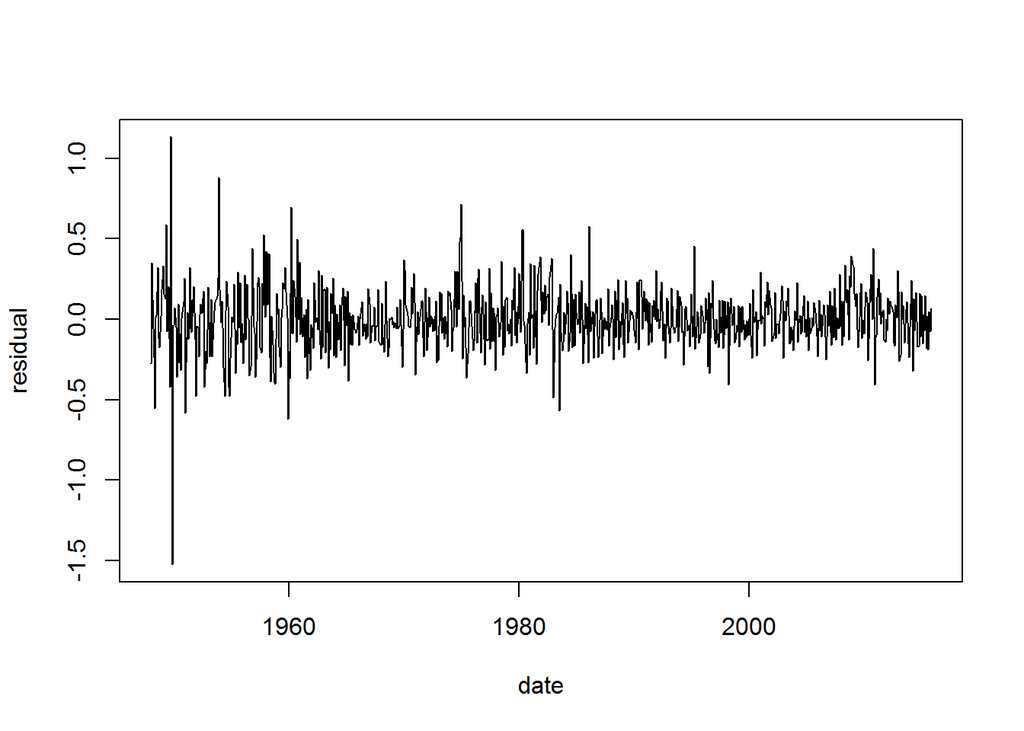

```r
plot(datas1$observation_date,resid,xlab = 'date',ylab = 'residual',type = 'l')
```

Construct fittef values from residual and original time series

```r
urateFit = urate-resid
```

Plot time series and fitted values

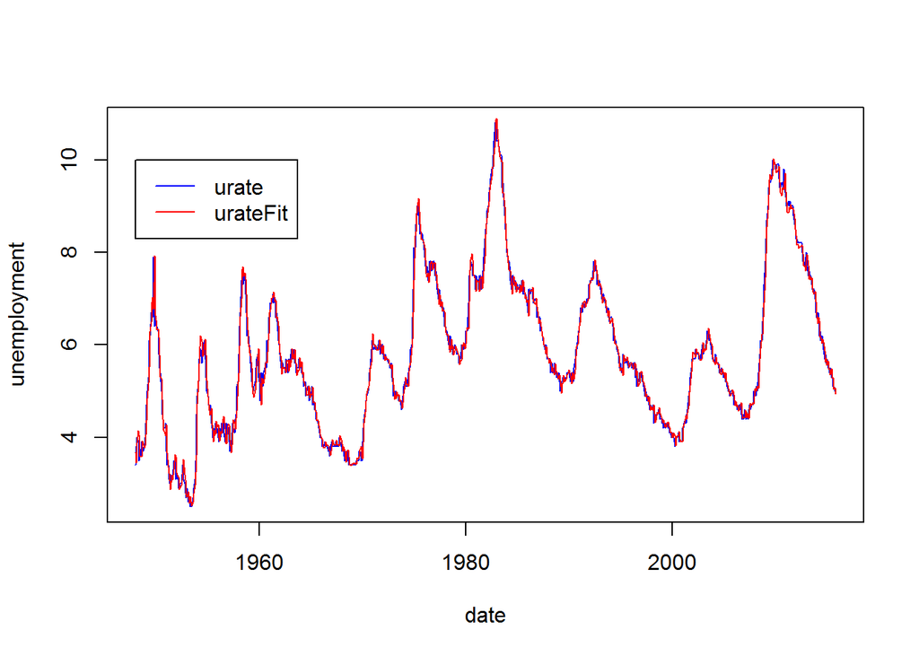

```r
plot(datas1$observation_date, urate, xlab = 'date', ylab = 'unemployment', type='l',col='blue')
lines(datas1$observation_date, urateFit,col='red')
legend(min(datas1$observation_date),10,c('urate','urateFit'),col = c('blue','red'),lty = c(1,1))
```

## Consumer Price Index

### Part 1

Plot raw data

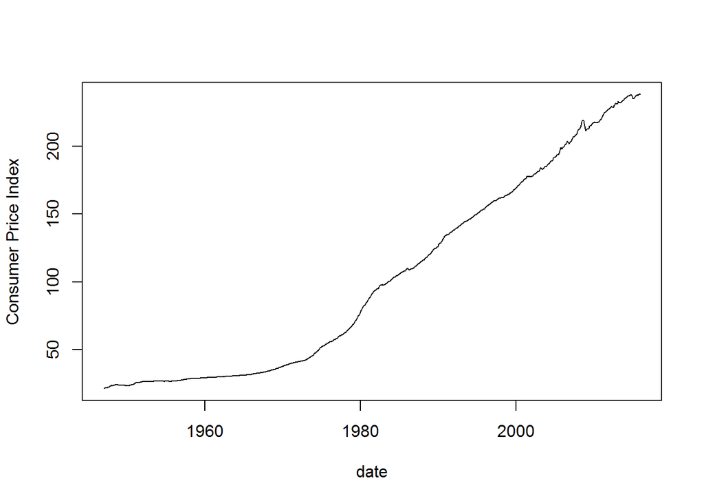

```r
plot(datas2$observation_date, datas2$CPIAUCSL, xlab = 'date', ylab = 'Consumer Price Index', type='l')
```

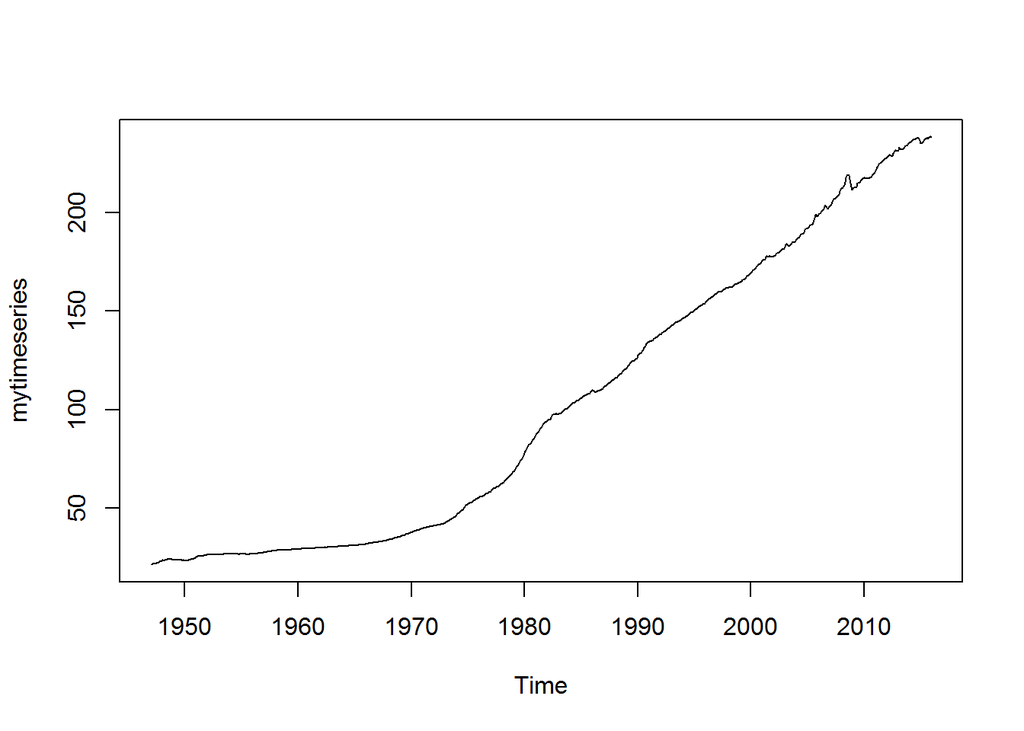

```r
mytimeseries = ts(data = datas2$CPIAUCSL, start = 1947, frequency = 12)
plot(mytimeseries)
```

```r
class(mytimeseries)
```

```
## [1] "ts"
```

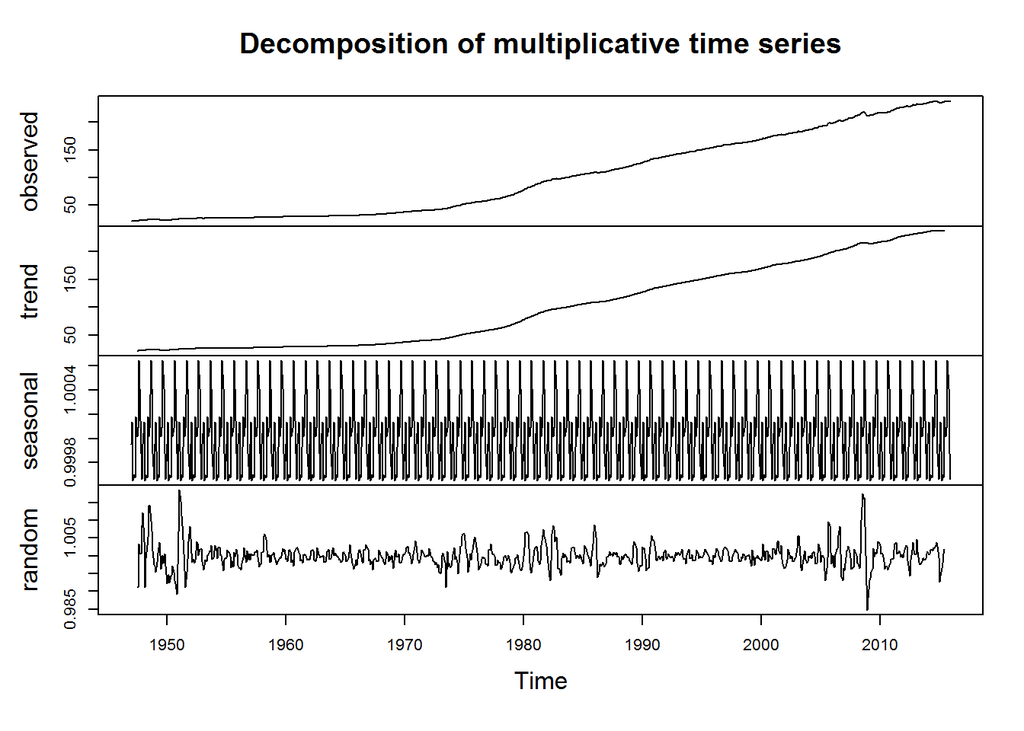

```r
#decompose(mytimeseries, "multiplicative") # decompose is in R base
plot(decompose(mytimeseries, type = "multiplicative"))
```

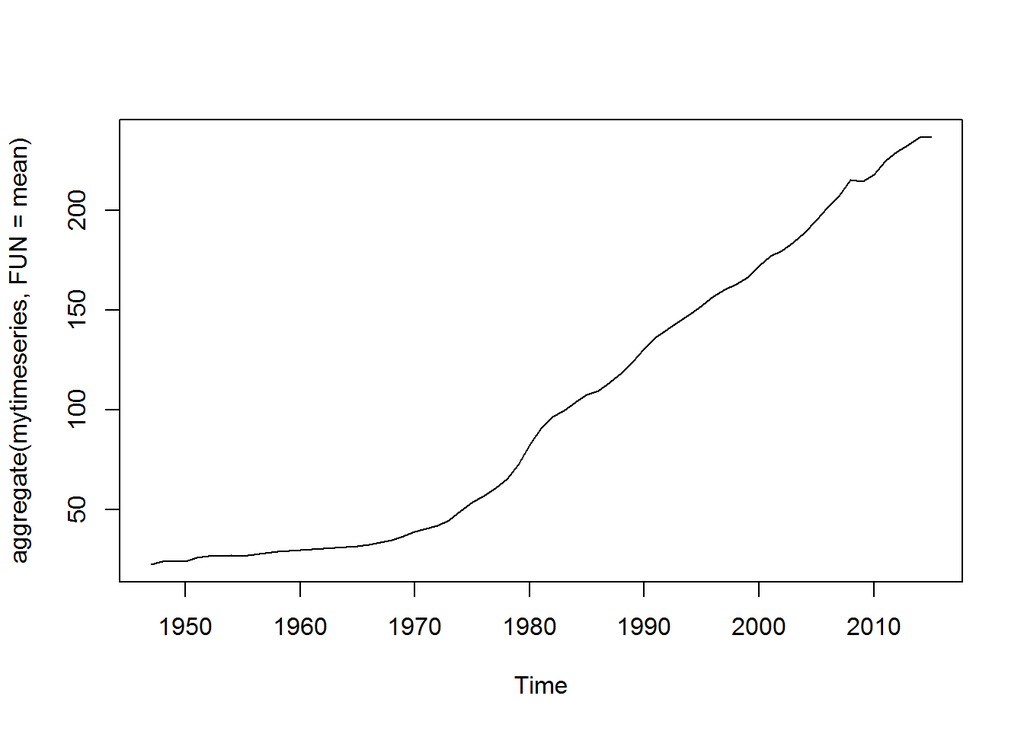

```r
plot(aggregate(mytimeseries,FUN=mean))
```

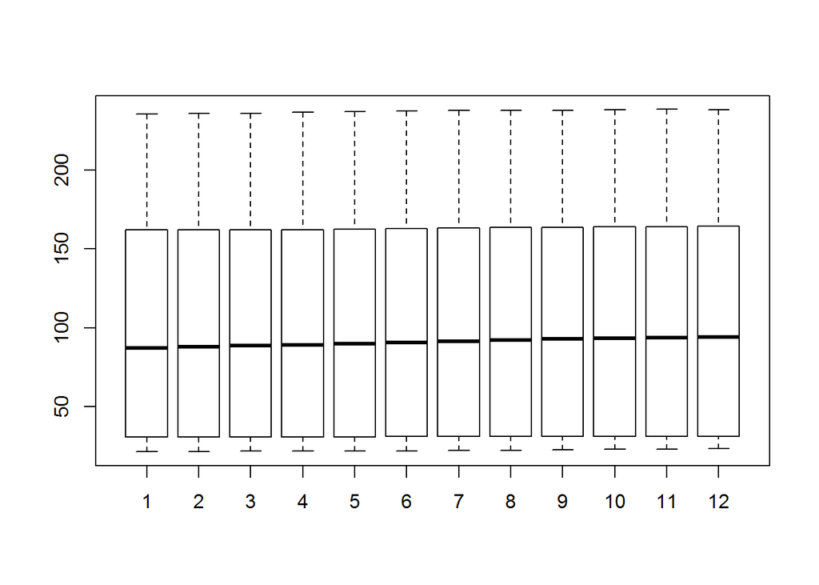

```r
boxplot(mytimeseries~cycle(mytimeseries))
```

There is clear indication of trend when we decompose the time series  
There is no indication of seasonality when we decompose the time series

Augmented Dickey-Fuller test for non-stationarity on the differene log transformed

```r
adf.test(datas2$CPIAUCSL, alternative="stationary", k=1)
```

```
##
##  Augmented Dickey-Fuller Test
##
## data:  datas2$CPIAUCSL
## Dickey-Fuller = -2.842, Lag order = 1, p-value = 0.2219
## alternative hypothesis: stationary
```

The (augmented) Dickey-Fuller test indicates non-stationarity. therefore we proceed with log transformation

```r
CPIAUCSL = diff(log(datas2$CPIAUCSL))
pValue = adf.test(CPIAUCSL,k=1)$p.value
adf.test(diff(log(datas2$CPIAUCSL)), alternative="stationary", k=0)
```

```
##
##  Augmented Dickey-Fuller Test
##
## data:  diff(log(datas2$CPIAUCSL))
## Dickey-Fuller = -14.928, Lag order = 0, p-value = 0.01
## alternative hypothesis: stationary
```

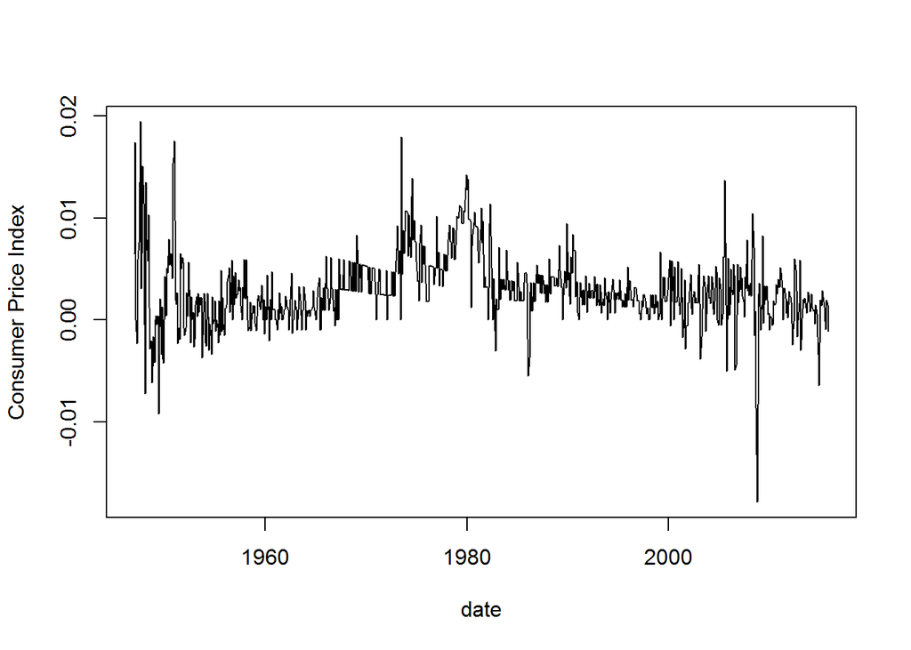

```r
plot(datas2$observation_date[1:length(datas2$observation_date)-1], CPIAUCSL, xlab = 'date', ylab = 'Consumer Price Index', type='l')
```

## Part 2

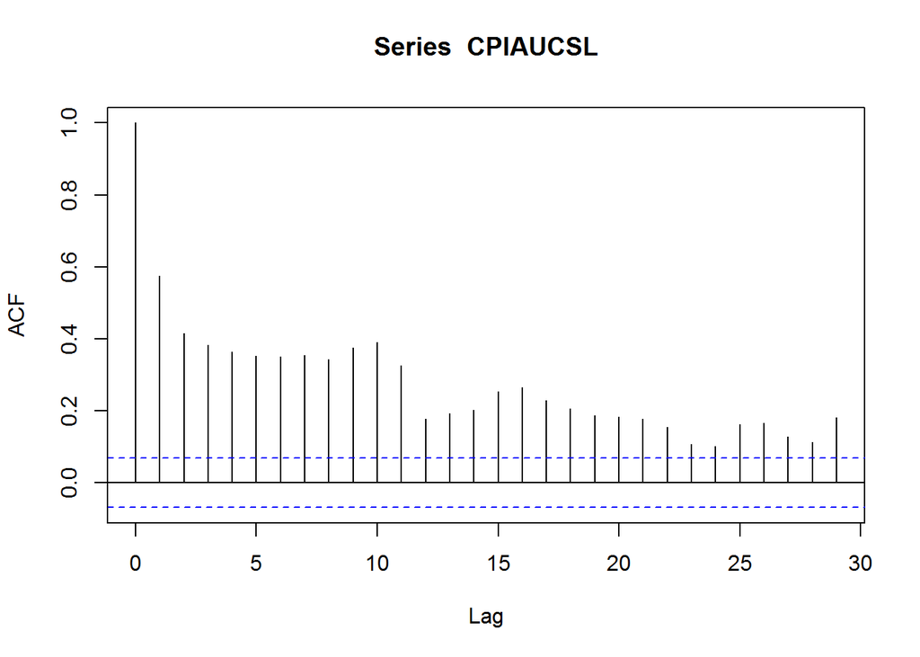

```r
acf(CPIAUCSL)
```

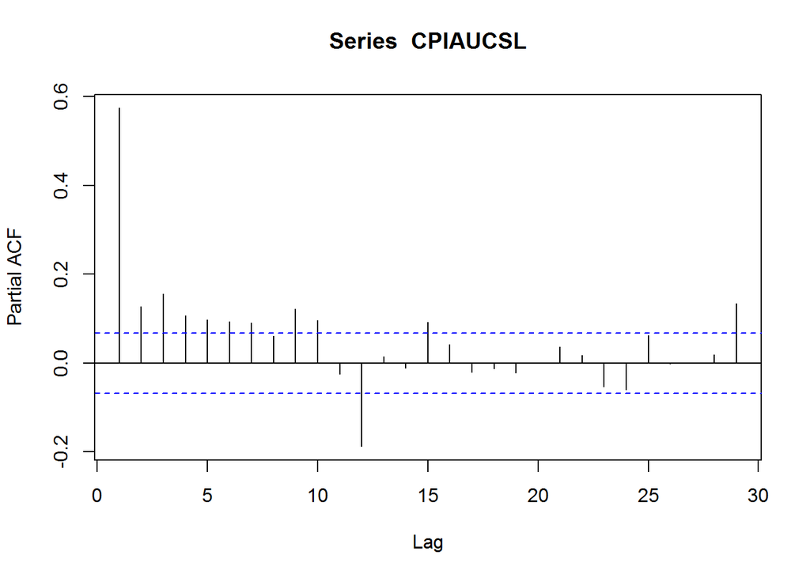

```r
pacf(CPIAUCSL)
```

Display the autocorrelations

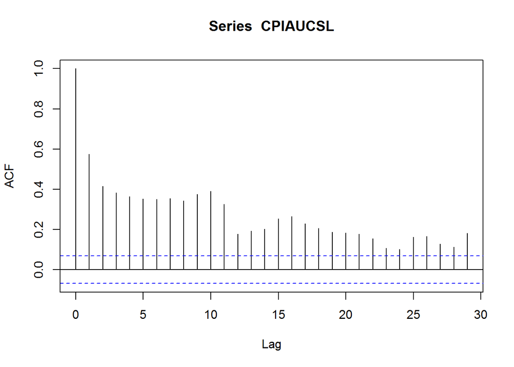

```r
CPIAUCSLAutocorrs = acf(CPIAUCSL)$acf
```

# Perform LBQ tests for significance of autocorrelations

```r
Box.test(CPIAUCSL, lag = 1)
```

```
##
##  Box-Pierce test
##
## data:  CPIAUCSL
## X-squared = 272.8, df = 1, p-value < 0.00000000000000022
```

```r
Box.test(CPIAUCSL, lag = 10)
```

```
##
##  Box-Pierce test
##
## data:  CPIAUCSL
## X-squared = 1294.9, df = 10, p-value < 0.00000000000000022
```

```r
# The serial correlation is statistically significant. i.e there is correlation
```

## Part 3

Test out different combinations of AR and MA terms and use AIC and BIC to determine fit

```r
maxAR = 4; # max of 4 AR terms
maxMA = 4; # max of 4 MA terms

CPIAUCSLModelCriteria = matrix(0,(maxAR+1)*(maxMA+1)-1,2)
ind = 1
lagCombinations = CPIAUCSLModelCriteria;

# Double for loop over AR and MA lags

for(ii in 0:maxMA){
  for (jj in 0:maxAR) {
    if(ii != 0 || jj != 0){
      CPIAUCSLModelCriteria[ind,1] = AIC(arima(CPIAUCSL, order = c(ii, 0 ,jj)))
      CPIAUCSLModelCriteria[ind,2] = BIC(arima(CPIAUCSL, order = c(ii, 0 ,jj)))
      lagCombinations[ind,] = matrix(c(ii,jj),1,2)
      ind = ind+1
    }

  }
}

# Find models with lowest AIC and BIC criteria, corresponding to best statistical fit
minIndices = apply(CPIAUCSLModelCriteria,2,which.min)

# Store the number of AR and MA terms associated with best model according to AIC
bestAICModelLags = lagCombinations[minIndices[1],]
bestAICModelLags
```

```
## [1] 3 4
```

Estimate model chosen by AIC

```r
library(lmtest)
modelEstimate = arima(CPIAUCSL,order=c(lagCombinations[minIndices[1],1],0,lagCombinations[minIndices[1],2]) )
coeftest(modelEstimate)
```

```
##
## z test of coefficients:
##
##              Estimate  Std. Error  z value              Pr(>|z|)
## ar1        0.06801928  0.02869973   2.3700             0.0177865 *
## ar2       -0.09200841  0.02697127  -3.4113             0.0006464 ***
## ar3        0.92152373  0.02409363  38.2476 < 0.00000000000000022 ***
## ma1        0.35826670  0.04530932   7.9071  0.000000000000002634 ***
## ma2        0.25433402  0.03861492   6.5864  0.000000000045056503 ***
## ma3       -0.74739178  0.03812580 -19.6033 < 0.00000000000000022 ***
## ma4       -0.19779787  0.03931387  -5.0312  0.000000487294572111 ***
## intercept  0.00291408  0.00059805   4.8726  0.000001101125382122 ***
## ---
## Signif. codes:  0 '***' 0.001 '**' 0.01 '*' 0.05 '.' 0.1 ' ' 1
```

```r
##  estimates are statistically significant
```

## Part 4

```r
# Save residuals from fitted ARMA model
resid = modelEstimate$residual
# Test for serial correlation
Box.test(resid,lag = 10)
```

```
##
##  Box-Pierce test
##
## data:  resid
## X-squared = 16.107, df = 10, p-value = 0.0966
```

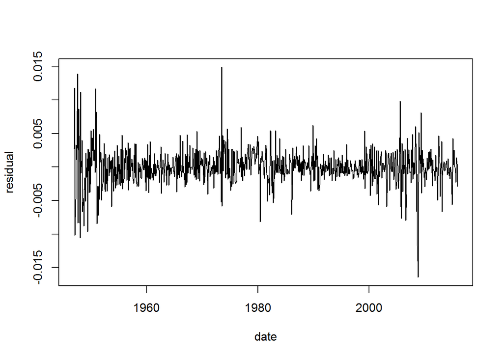

```r
# Visually inspect fitted residuals
plot(datas2$observation_date[1:length(datas2$observation_date)-1],resid,xlab = 'date',ylab = 'residual',type = 'l')
```

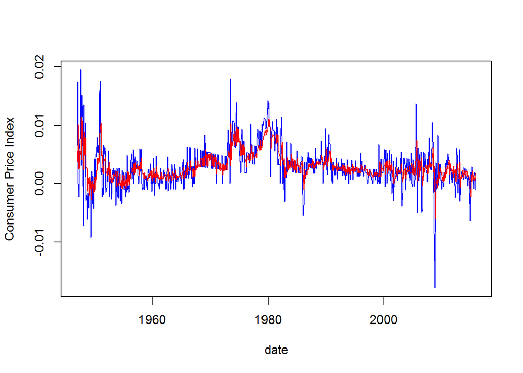

```r
# Construct fittef values from residual and original time series
CPIAUCSLFit = CPIAUCSL-resid

#Plot time series and fitted values
plot(datas2$observation_date[1:length(datas2$observation_date)-1], CPIAUCSL, xlab = 'date', ylab = 'Consumer Price Index', type='l',col='blue')
lines(datas2$observation_date[1:length(datas2$observation_date)-1], CPIAUCSLFit,col='red')
legend(min(datas2$observation_date[1:length(datas2$observation_date)-1]),10,c('CPIAUCSL','CPIAUCSLFit'),col = c('blue','red'),lty = c(1,1))
```

## Gold Fixing Price

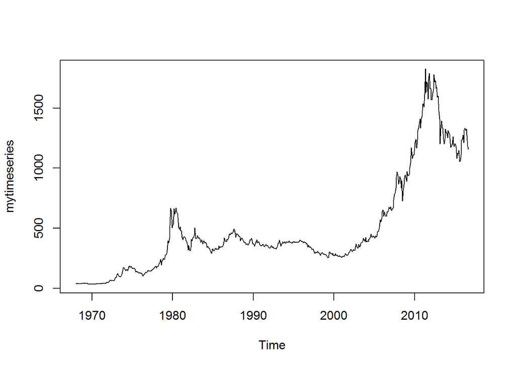

```r
colnames(datas3) <- c("observation_date","GOLDPrice")
###############
# GOLD = diff(log(datas3$GOLDPrice))

mytimeseries = ts(data = datas3$GOLDPrice, start = 1968, frequency = 12)
plot(mytimeseries)
```

```r
class(mytimeseries)
```

```
## [1] "ts"
```

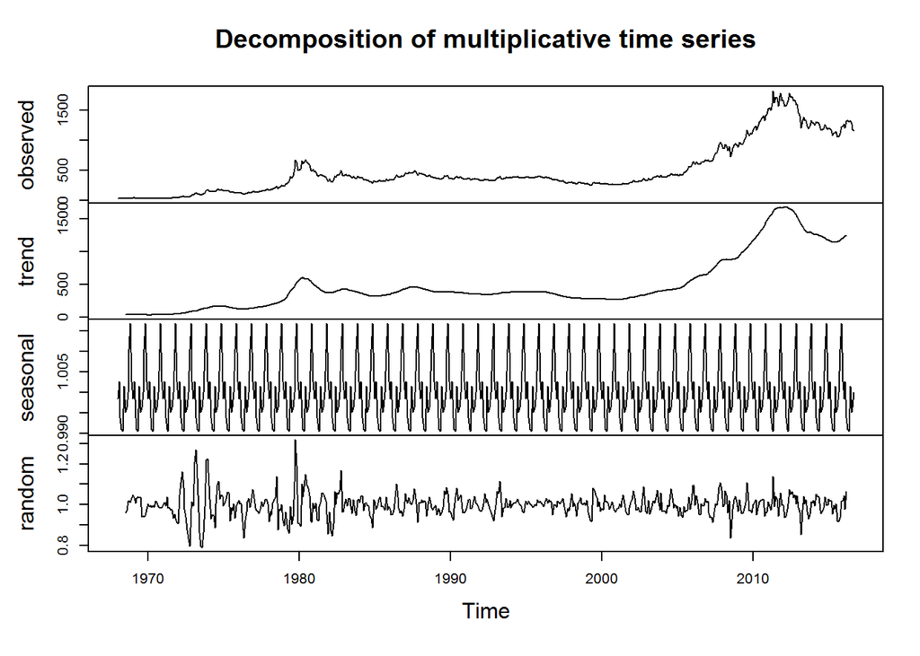

```r
#decompose(mytimeseries, "multiplicative") # decompose is in R base
plot(decompose(mytimeseries, type = "multiplicative"))
```

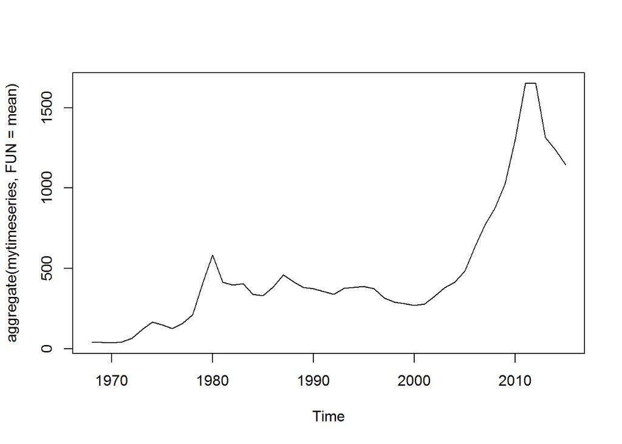

```r
plot(aggregate(mytimeseries,FUN=mean))
```

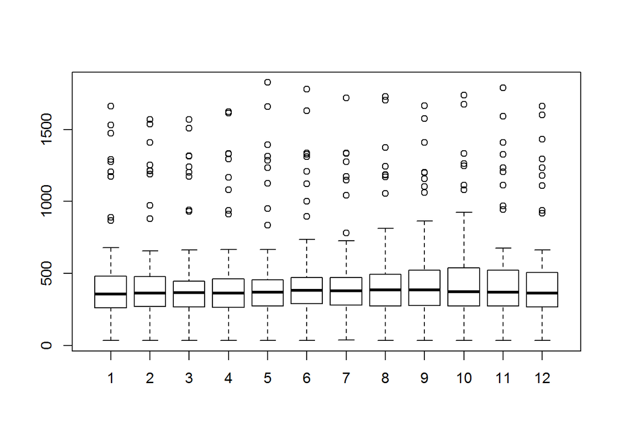

```r
boxplot(mytimeseries~cycle(mytimeseries))
```

## Part 1

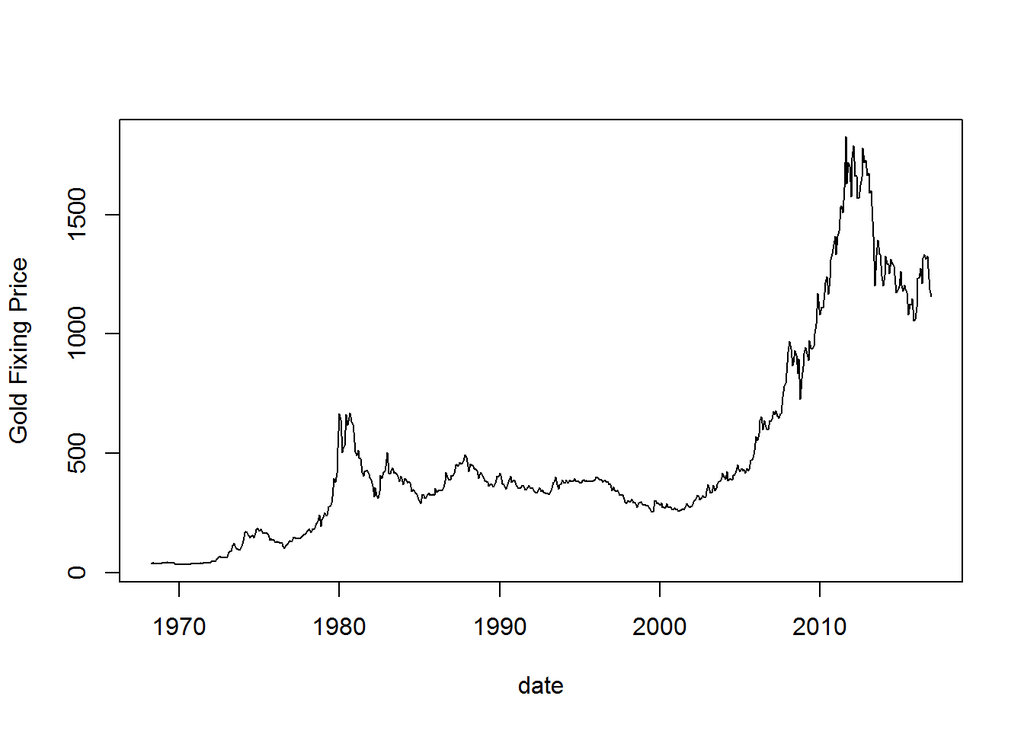

```r
# Plot raw data

plot(datas3$observation_date, datas3$GOLDPrice, xlab = 'date', ylab = 'Gold Fixing Price', type='l')
```

```r
#  Augmented Dickey-Fuller test for non-stationarity on the differene log transformed
## The (augmented) Dickey-Fuller test indicates non-stationarity. therefore we proceed with log transformation
adf.test(datas3$GOLDPrice, alternative="stationary", k=1)
```

```
##
##  Augmented Dickey-Fuller Test
##
## data:  datas3$GOLDPrice
## Dickey-Fuller = -1.5491, Lag order = 1, p-value = 0.7692
## alternative hypothesis: stationary
```

```r
GOLD = diff(log(datas3$GOLDPrice))
pValue = adf.test(GOLD,k=1)$p.value
```

plot the transformed series, and use this in the further analysis.

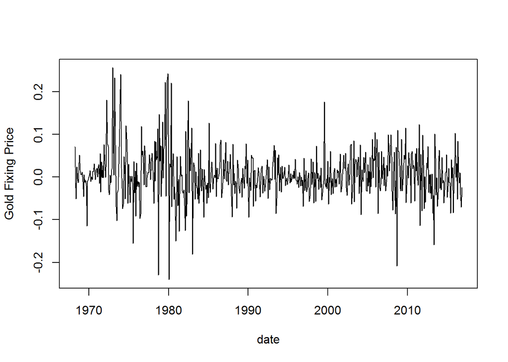

```r
plot(datas3$observation_date[1:length(datas3$observation_date)-1], GOLD, xlab = 'date', ylab = 'Gold Fixing Price', type='l')
```

## Part 2

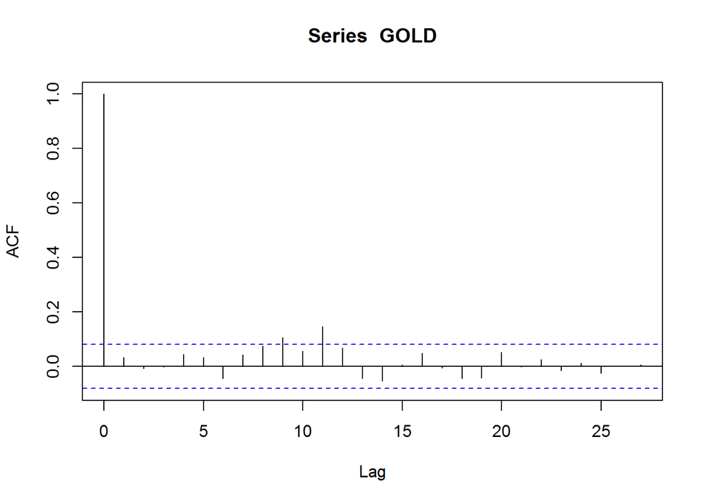

```r
# Plot the autocorrelation function for the first 10 lags
acf(GOLD)
```

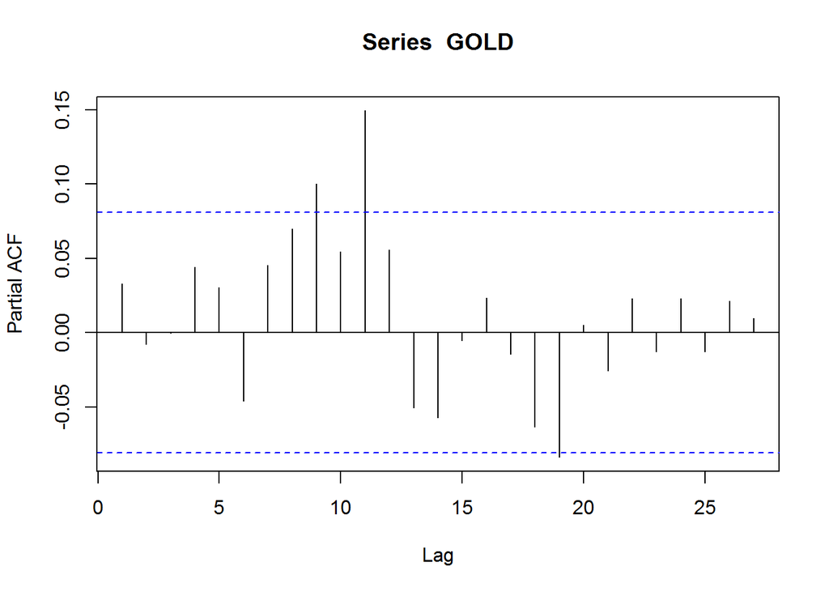

```r
pacf(GOLD)
```

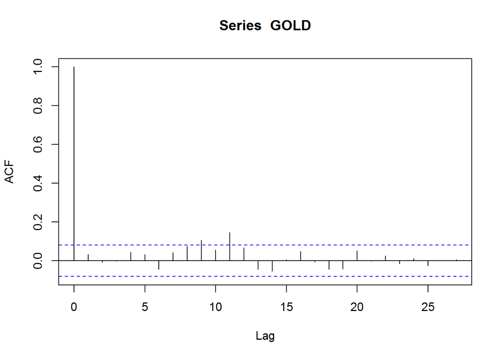

```r
# Display the autocorrelations
GOLDAutocorrs = acf(GOLD)$acf
```

```r
#Perform LBQ tests for significance of autocorrelations
Box.test(GOLD, lag = 1)
```

```
##
##  Box-Pierce test
##
## data:  GOLD
## X-squared = 0.62766, df = 1, p-value = 0.4282
```

```r
Box.test(GOLD, lag = 10)
```

```
##
##  Box-Pierce test
##
## data:  GOLD
## X-squared = 16.239, df = 10, p-value = 0.093
```

The serial correlation is not statistically significant. i.e there no is correlation